# Beta Distribution

April 28, 2020

## Chapter 7

**Section 7.3**

## Beta Function

*Definition.*

The **beta function**, denoted \( B(\alpha, \beta) \), but I will use \( B(a,b) \), is defined as

\[ B(a,b) = \int\limits_{0}^{1}x^{a-1}(1-x)^{b-1}dx \]

where \( a,b \) are positive real values, \( a, b > 0 \).

*Example.*

\[ B(3,2) = \int\limits_{0}^{1}x^{3-1}(1-x)^{2-1}dx = \int\limits_{0}^{1}x^{2}(1-x)dx = \int\limits_{0}^{1}x^2-x^3dx = \frac{1}{12} \]

\[ B(1/2,1) = \int\limits_{0}^{1}x^{(1/2)-1}(1-x)^{1-1}dx = \int\limits_{0}^{1}x^{-1/2}dx = 2 \]

## Beta Function

*Result.*

For \( a > 0 \) and \( b > 0 \)

\[ B(a,b) = \frac{\Gamma(a)\Gamma(b)}{\Gamma(a+b)} \]

*Example.*

\[ B(3,2) = \frac{\Gamma(3)\Gamma(2)}{\Gamma(5)} = \frac{2!1!}{4!} = \frac{1}{12} \]

*Note.*

\[ B(a,b) = B(b,a) \]

## Beta Distribution

*Definition.*

A continuous random variable \( \small X \) is said to have a **Beta distribution** with parameters \( a > 0 \) and \( b > 0 \) if the density of \( \small X \) is given by

\[ \large f(x) = \frac{x^{a-1}(1-x)^{b-1}}{B(a,b)}1_{(0,1)}(x) \]

We write \( X \sim Beta(a,b) \).

*Note.*

\[ f(x) = \frac{\Gamma(a+b)}{\Gamma(a)\Gamma(b)}x^{a-1}(1-x)^{b-1}1_{(0,1)}(x) \]

*Notes.*

Beta distribution can be effective for random variables that are proportions or percentages, constrained to \( \small (0,1) \).

Distribution explores random variables on the space \( \small (0,1) \) and is capable of many shapes.

### Properties of Beta distribution

\[ f(x) = \frac{\Gamma(a+b)}{\Gamma(a)\Gamma(b)}x^{a-1}(1-x)^{b-1}1_{(0,1)}(x) \]

Let \( \small X \sim Beta(a,b) \)

(1) Consider \( x \to 0 \)

\[ \begin{cases} f(x) \to \infty & 0 < a < 1 \\ f(x) = b & a = 1 \\ f(x) \to 0 & a > 1 \end{cases} \]

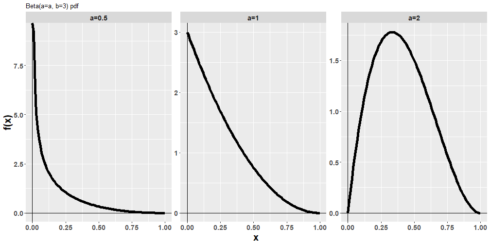

### Properties of Beta distribution

\[ f(x) = \frac{\Gamma(a+b)}{\Gamma(a)\Gamma(b)}x^{a-1}(1-x)^{b-1}1_{(0,1)}(x) \]

Let \( \small X \sim Beta(a,b) \)

(1) Consider \( x \to 1 \)

\[ \begin{cases} f(x) \to \infty & 0 < b < 1 \\ f(x) = a & b = 1 \\ f(x) \to 0 & b > 1 \end{cases} \]

The right hand side behavior is controlled by \( \small b \).

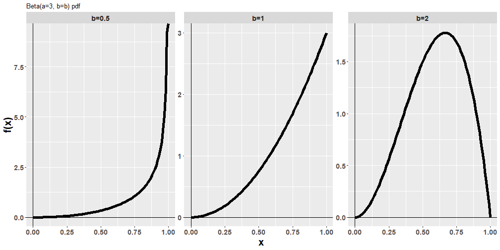

### Properties of Beta distribution

\[ f(x) = \frac{\Gamma(a+b)}{\Gamma(a)\Gamma(b)}x^{a-1}(1-x)^{b-1}1_{(0,1)}(x) \]

Let \( \small X \sim Beta(a,b) \)

(3) When \( \small a=b \), the density function is symmetric around \( \small x=1/2 \).

(4) There is no general closed form for the CDF. Does exists for certain combinations of \( \small a,b \) (integers create polynomials).

(5) Many critical points to study.

- \( \small x=0 \) when \( \small a > 2 \) similarly \( \small x = 1 \) when \( \small b > 2 \)
- \( \small x = \frac{a-1}{a+b-2} \) is a *maximum* when \( a > 1 \) and \( b > 1 \).

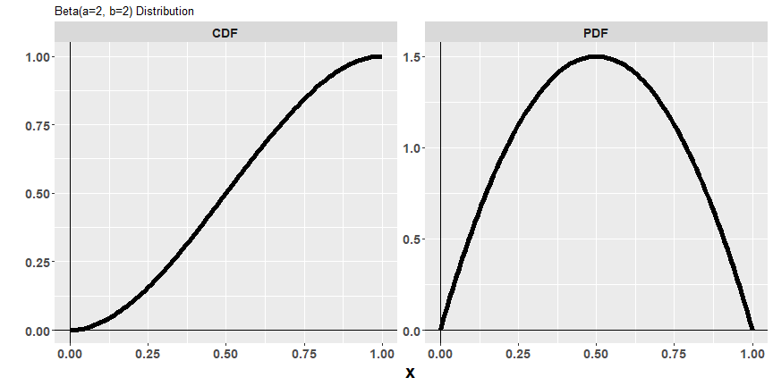

### Beta Distribution in R

```r
dbeta(x, a, b) #pdf
pbeta(x, a, b) #cdf
qbeta(q, a, b) #quantile
```

A few unique shapes.

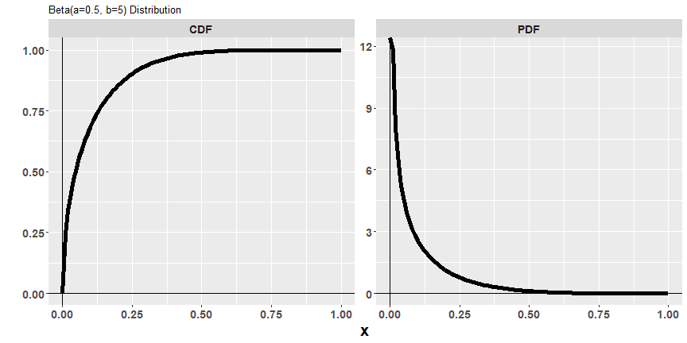

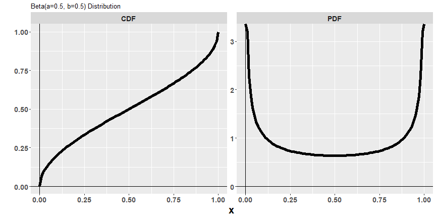

## Beta Distribution

*Results.*

Let \( \small X \sim Beta(a,b) \), then

(1) \[ E[X] = \frac{a}{a+b} \]

(2) \[ V[X] = \frac{ab}{(a+b)^2(a+b+1)} \]

### Proof of mean and variance of Beta(a,b)

Consider \( \small X \sim Beta(a,b) \). Let \( \small k > 0 \).

\[ \begin{aligned} E[X^k] &= \int\limits_{-\infty}^{\infty}x^kf(x)dx = \int\limits_{0}^{1}\frac{\Gamma(a+b)}{\Gamma(a)\Gamma(b)}x^kx^{a-1}(1-x)^{b-1}dx \\ &= \frac{\Gamma(a+b)}{\Gamma(a)\Gamma(b)}\int\limits_{0}^{1}x^{k+a-1}(1-x)^{b-1}dx \\ \end{aligned} \]

We use the common trick again of recognizing the 'kernel' of a known distribution, which allows us to know results of these integrals without having to perform the calculus (using what we know about probability functions instead). Here, recognize that the integral

\[ \int\limits_{0}^{1}x^{k+a-1}(1-x)^{b-1}dx \]

is what we call the **kernel** of a distribution that follows a \( \small Beta(a+k, b) \) distribution. It is just missing the normalizing constant. We know that if the constant was there, this should integrate to one, thus this must integrate to the 'reciprocal' of the normalizing constant, or..

\[ \int\limits_{0}^{1}x^{k+a-1}(1-x)^{b-1}dx = \frac{\Gamma(a+k)\Gamma(b)}{\Gamma(a+k+b)} \]

### Proof of mean and variance of Beta(a,b)

Substituting we obtain

\[ \begin{aligned} E[X^k] &= \frac{\Gamma(a+b)\Gamma(a+k)}{\Gamma(a)\Gamma(a+b+k)}\cdot\frac{\Gamma(b)}{\Gamma(b)} \end{aligned} \]

Then we can find the expectation, \( \small E[X] \),

\[ E[X] = E[X^1] = \frac{\Gamma(a+b)\Gamma(a+1)}{\Gamma(a)\Gamma(a+b+1)}= \frac{a\Gamma(a)}{\Gamma(a)}\cdot\frac{\Gamma(a+b)}{(a+b)\Gamma(a+b)} = \frac{a}{a+b} \]

Similarly, it can be shown that

\[ E[X^2] = \frac{(a+1)a}{(a+b+1)(a+b)} \]

which can be used to prove the variance result.

### Beta Distribution Example

Let \( \small X \sim Beta(1,5) \) where \( \small X \) describes the proportion of the daily stock of bread sold at a grocery store.

The density function for this distribution is

\[ f(x) = \frac{x^{1-1}(1-x)^{5-1}}{B(1,5)} = \frac{\Gamma(6)}{\Gamma(1)\Gamma(5)}(1-x)^4 = \frac{5!}{4!}(1-x)^4 = 5(1-x)^4 \]

To include the support, we can write \( f(X) = 5(1-x)^41_{(0,1)}(x) \).

This beta distribution is a polynomial, we can find the cdf.

\[ F(x) = \int\limits_{0}^{x}5(1-t)^4dt = \left.\frac{-5(1-t)^5}{5}\right|_0^x = -(1-x)^5 + (1)^5 = 1-(1-x)^5 \]

To define for all real values, I write

\[ F(X) = 1-(1-x)^51_{(0,1)}(x) + 1_{[1,\infty]} \]

### Beta Distribution Example

\[ X \sim Beta(1,5) \]

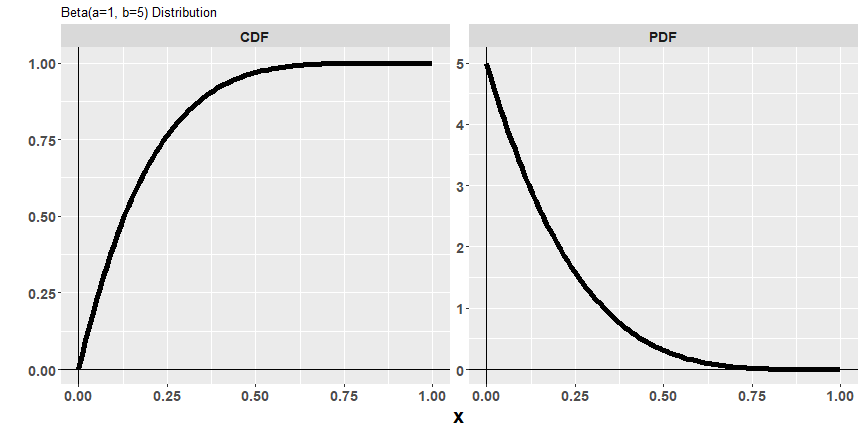

### Beta Distribution Example

**What percent of bread is sold \( 60\% \) of the time?**

- What value of \( c \), the percent of bread sold, captures \( 60\% \) of the possible outcomes?
- Sixty percent of the time the amount sold will be less than or equal to \( c \).

These are all ways of asking for the 60th percentile.

\[ \begin{aligned} P(X < c) = 0.6 &\implies F(c) = 0.6 \implies 1-(1-c)^5 = 0.6 \\ &\implies 1 - c = (0.4)^{1/5} \implies c = 1 - (0.4)^{1/5} \approx 0.1674 \text{ or } 16.74\% \end{aligned} \]

That is, there is a \( 60\% \) probability that \( 16.74\% \) of the daily stock or less will be sold.

**What percent of the break stock captures \( 90\% \)? (The 90th percentile)**

\[ P(X < c) = 0.9 \implies c = 1-(0.1)^{1/5} \approx 0.369 \text{ or } 36.9\% \]

**What is the expected percent of the daily bread stock that will be sold?**

\[ \mu_X = \frac{a}{a+b} = \frac{1}{1+5} = \frac{1}{6} \approx 0.1667 \text{ or } 16.67\% \]

**What is the median percent of bread sold?**

\[ F(m) = 0.5 \implies m = 0.1294 \text{ or } 12.94\% \]